# R, DOT, and TikZ code to plot DAGs and SWIGs for Mendelian randomization analyses

Tom Palmer

2022-04-07

# Introduction

This webpage shows some R code for generating figures, directed acyclic graphs (DAGs), and single world intervention graphs (SWIGs) for Mendelian randomization (MR) analyses.

First, we load in the tidyverse collection of packages to have access to the pipe and the ggplot2 package, amongst other features.

```r
library(tidyverse)
```

If you do not already one you will need a LaTeX installation. In R it is easiest to install [TinyTeX](https://yihui.org/tinytex/) as follows.

```r
install.packages("tinytex")
tinytex::install_tinytex()
```

# DiagrammeR package

The website for DiagrammeR is here: http://rich-iannone.github.io/DiagrammeR/ .

We will draw the DAGs using Graphviz which uses the DOT language to describe graphs.

## Single genotype DAG

```r
DiagrammeR::grViz("
      digraph mrdag {

      graph [rankdir=TB]

      node [shape=ellipse]
      U [label='Confounders']

      node [shape=box, height=0.3, width=0.3]
      G [label='Genotype']
      X [label='Phenotype']
      Y [label='Outcome']

      { rank = same; G X Y }

      G -> X [minlen=3]
      U -> X
      U -> Y
      X -> Y [minlen=3]
      }
      ", height = 200)
```

[interactive chart not shown]

### Version without borders around observed variables

```r
DiagrammeR::grViz("
      digraph mrdag {

      graph [rankdir=TB]

      node [shape=ellipse]
      U [label='Confounders']

      node [shape=plaintext, height=0.3, width=0.3]
      G [label='Genotype']
      X [label='Phenotype']
      Y [label='Outcome']

      { rank = same; G X Y }

      G -> X [minlen=3]
      U -> X
      U -> Y
      X -> Y [minlen=3]
      }
      ", height = 200)
```

[interactive chart not shown]

## Multiple genotype DAG

```r
DiagrammeR::grViz("
      digraph mrdag {

      graph [rankdir=TB, layout=neato]

      node [shape=ellipse]
      U [label='Confounders', pos='3,1!']

      node [shape=box, height=0.3, width=0.3]
      G1 [label='<I>G@_{1}</I>', pos='0,0.75!']
      G2 [label='<I>G@_{2}</I>', pos='0,0!']
      G3 [label='<I>G@_{3}</I>', pos='0,-0.75!']
      X [label='Phenotype', pos='2,0!']
      Y [label='Outcome', pos='4,0!']

      { rank = same; G2 X Y }

      G1 -> X
      G2 -> X
      G3 -> X
      U -> X
      U -> Y
      X -> Y
      }
      ", height = 200)
```

[interactive chart not shown]

This could be extended for more genotypes.

### Version without borders around observed variables

```r
DiagrammeR::grViz("
      digraph mrdag {

      graph [rankdir=TB, layout=neato]

      node [shape=ellipse]
      U [label='Confounders', pos='3,1!']

      node [shape=plaintext, height=0.3, width=0.3]
      G1 [label='<I>G@_{1}</I>', pos='0,0.75!']
      G2 [label='<I>G@_{2}</I>', pos='0,0!']
      G3 [label='<I>G@_{3}</I>', pos='0,-0.75!']
      X [label='Phenotype', pos='2,0!']
      Y [label='Outcome', pos='4,0!']

      { rank = same; G2 X Y }

      G1 -> X
      G2 -> X
      G3 -> X
      U -> X
      U -> Y
      X -> Y
      }
      ", height = 200)
```

[interactive chart not shown]

## Single genotype path diagram

Explicitly including the confounder, $U$.

```r
DiagrammeR::grViz("
      digraph mrdag {

      graph [rankdir=TB, layout=neato]

      node [shape=ellipse, height=0.3, width=0.3]
      U [label=<<I>U</I>>, pos='3,1!']

      node [shape=box, height=0.3, width=0.3]
      G [label=<<I>G</I>>, pos='0,0!']
      X [label=<<I>X</I>>, pos='2,0!']
      Y [label=<<I>Y</I>>, pos='4,0!']

      node [shape=circle, height=0.35, fixedsize=true]
      Ex [label='<I>&epsilon;@_{X}</I>', pos='2,1!']
      Ey [label='<I>&epsilon;@_{Y}</I>', pos='4,1!']

      G -> X [label='<I>&beta;@_{GX}</I>']
      Ex -> X [label=1]
      Ey -> Y [label=1]
      U -> X [label='<I>&beta;@_{UX}</I>']
      U -> Y [label='<I>&beta;@_{UY}</I>']
      X -> Y [label='<I>&beta;@_{XY}</I>']
      U -> U [dir='both', headport='n', tailport='n']
      G -> G [dir='both', headport='w', tailport='w']
      }
      ", height = 200)
```

[interactive chart not shown]

Instead drawing correlated error terms between $X$ and $Y$.

```r
DiagrammeR::grViz("
      digraph mrdag {

      graph [rankdir=TB, layout=neato]

      node [shape=box, height=0.3, width=0.3]
      G [label=<<I>G</I>>, pos='0,0!']
      X [label=<<I>X</I>>, pos='2,0!']
      Y [label=<<I>Y</I>>, pos='4,0!']

      node [shape=circle, height=0.35, fixedsize=true]
      Ex [label='<I>&epsilon;@_{X}</I>', pos='2,1!']
      Ey [label='<I>&epsilon;@_{Y}</I>', pos='4,1!']

      G -> X [label='<I>&beta;@_{GX}</I>']
      Ex -> X [label=1]
      Ey -> Y [label=1]
      X -> Y [label='<I>&beta;@_{XY}</I>']
      Ex -> Ey [dir='both', label=<<I>&rho;</I>>]
      G -> G [dir='both', headport='w', tailport='w']
      }
      ", height = 200)
```

[interactive chart not shown]

# dagitty package

The website for DAGitty is here http://www.dagitty.net/

```r
library(dagitty)
```

## Using DOT syntax

The DAG for a single genotype.

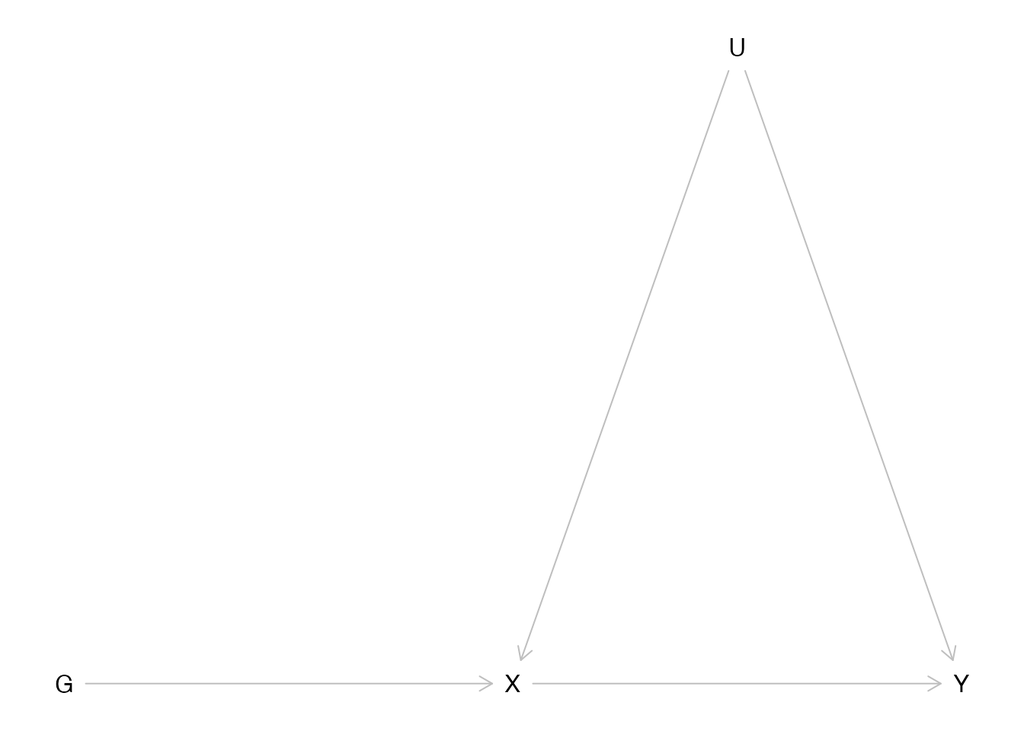

```r
mrdag <- dagitty('dag {
  G -> X -> Y
  X <- U -> Y
  G [pos="0,0"]
  X [e, pos="1,0"]
  U [pos="1.5,-0.4"]
  Y [o, pos="2,0"]
}')

plot(mrdag)
```

## Using ggdag

```r
library(ggdag)
```

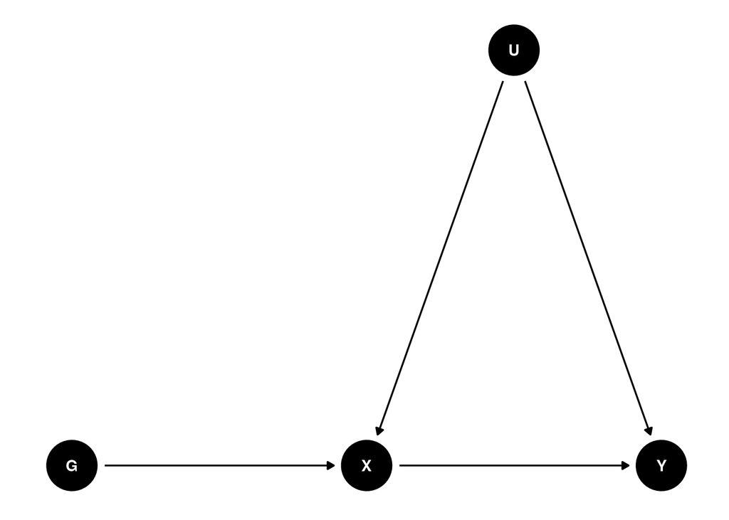

```r
mrdag <- dagitty('dag {
  G -> X -> Y
  X <- U -> Y
  G [pos="0,0"]
  X [e, pos="1,0"]
  U [pos="1.5,0.4"]
  Y [o, pos="2,0"]
}')

ggmrdag <- tidy_dagitty(mrdag)
ggdag(ggmrdag) + theme_dag()
```

This can be labelled as follows.

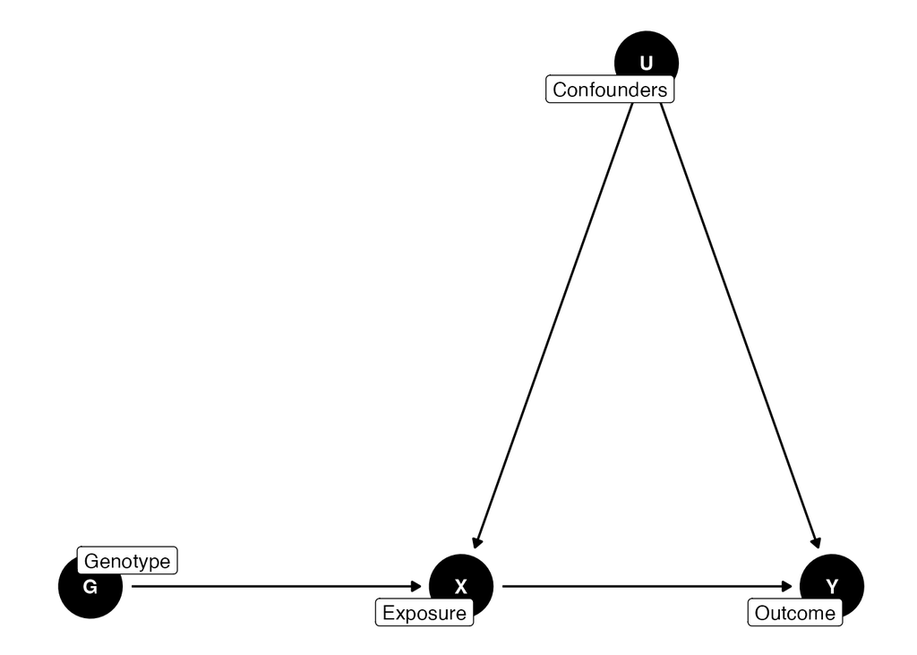

```r
mrdag <- mrdag %>%
  dag_label(
    labels = c(
      "X" = "Exposure",
      "Y" = "Outcome",
      "G" = "Genotype",
      "U" = "Confounders"))
ggdag(mrdag,  use_labels = "label") + theme_dag()
```

Dagitty can identify the instrumental variable on the DAG.

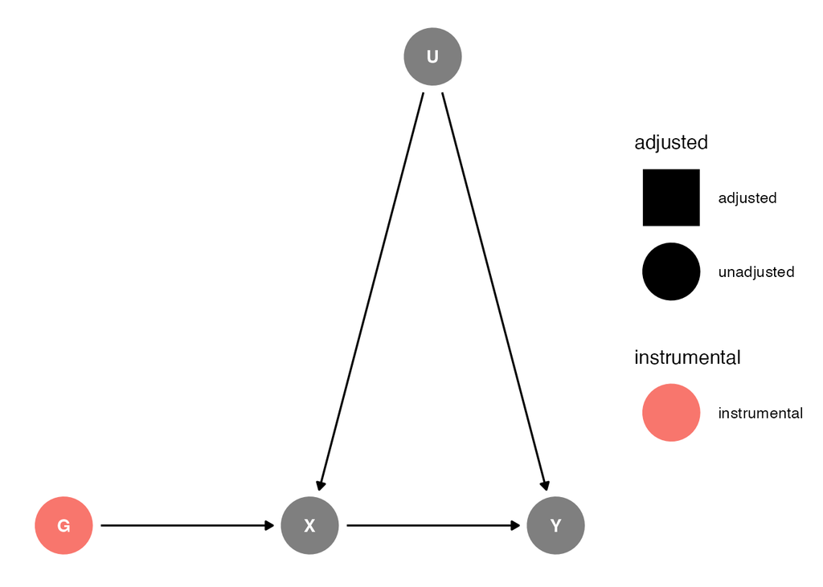

```r
mrdag %>% ggdag_instrumental() + theme_dag()
```

It correctly identifies the genotype, G, as the instrumental variable.

## Using R model type syntax in ggdag

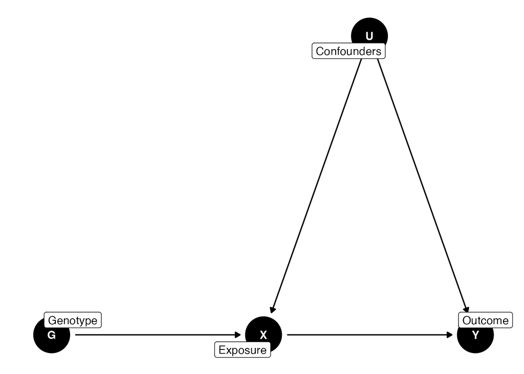

```r
coords <- list(x = c(
  G = 0,
  X = 1,
  Y = 2,
  U = 1.5
),
y = c(
  G = 0,
  X = 0,
  Y = 0,
  U = 1
))

mrdag <- dagify(
  X ~ G + U,
  Y ~ X + U,
  labels = c(
    "G" = "Genotype",
    "X" = "Exposure",
    "Y" = "Outcome",
    "U" = "Confounders"
  ),
  exposure = "X",
  outcome = "Y",
  coords = coords
)

ggdag(mrdag, use_labels = "label") + theme_dag()
```

Plotting directly with ggplot2 functions.

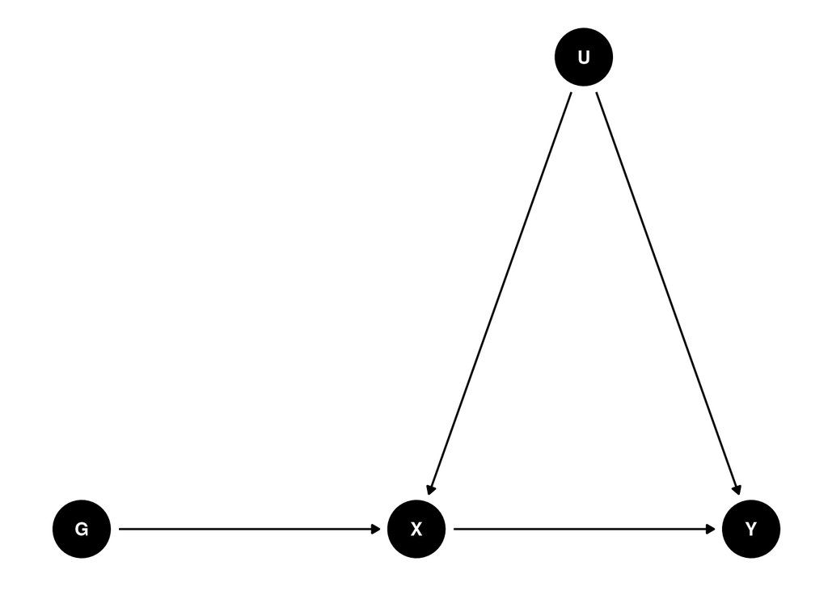

```r
mrdag %>%
  ggplot(aes(
    x = x,
    y = y,
    xend = xend,
    yend = yend
  )) +
  geom_dag_point() +
  geom_dag_edges() +
  geom_dag_text() +
  theme_dag()
```

Showing the paths.

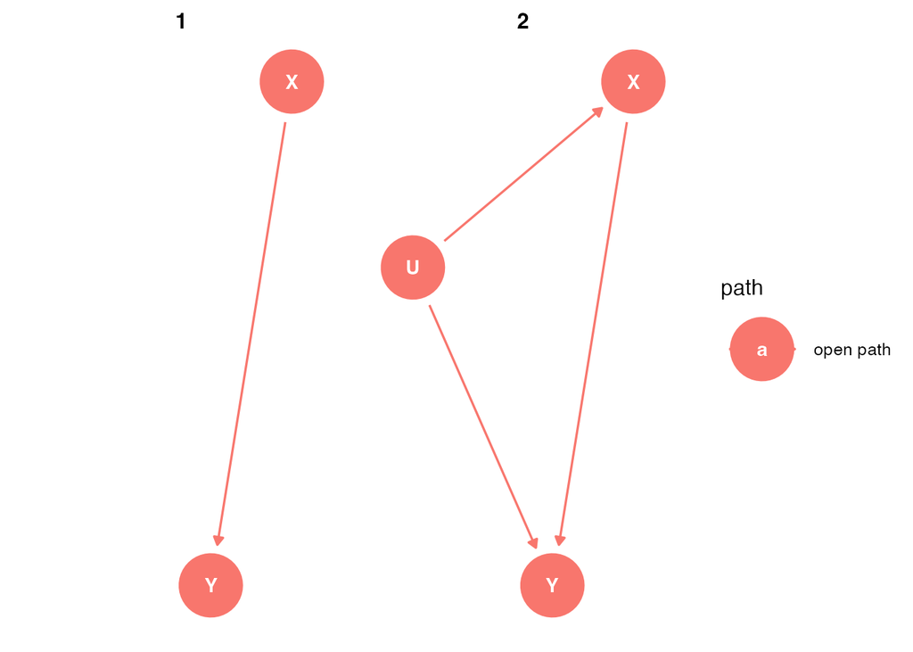

```r
dagify(Y ~ X + U,
       X ~ U + G,
       exposure = "X",
       outcome = "Y") %>%
ggdag_paths() + theme_dag()
```

Adjustment set for the effect of $X$ on $Y$.

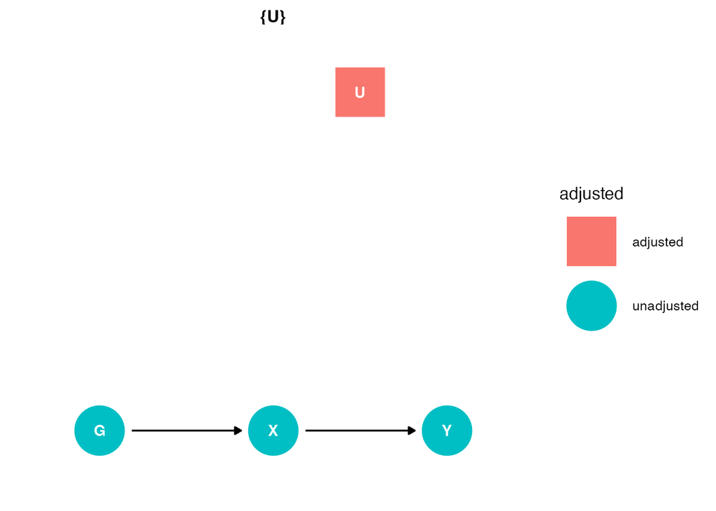

```r
dagify(Y ~ X + U,
       X ~ U + G,
       exposure = "X",
       outcome = "Y",
       coords = coords) %>%
  ggdag_adjustment_set() + theme_dag()
```

This shows that the path from G to X is unconfounded. And that when U is adjusted for the path from X to Y is unconfounded.

## Multiple genotype DAG

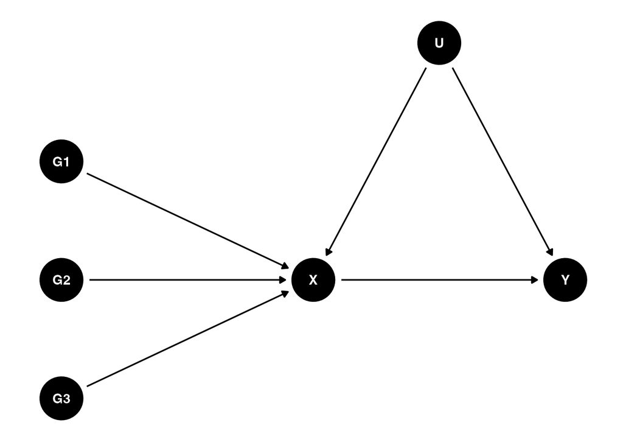

```r
coords2 <- list(x = c(G1 = 0, G2 = 0, G3 = 0, X = 1, Y = 2, U = 1.5),
                y = c(G1 = 0.5, G2 = 0, G3 = -0.5, X = 0, Y = 0, U = 1))

mrdag <- dagify(
  X ~ G1,
  X ~ G2,
  X ~ G3,
  Y ~ X,
  X ~ U,
  Y ~ U,
  exposure = "X",
  outcome = "Y",
  coords = coords2
)

ggdag(mrdag) + theme_dag()
```

This could be extended for more genotypes.

# Eleanor Murray’s TikZ diagrams using the tikz code chunk engine

I believe that tikz diagrams can be included in Rmarkdown documents using the tikz code chunk engine for output types `pdf_document` and `html_document`.

Tikz is a package for LaTeX and so pdf is its natural output. So far I have not been able to include these figures in either `html_notebook` or `word_document` output formats. I suspect that the images need conversion to png files for these to work under rmarkdown.

We will use some of the LaTeX code for drawing DAGs using tikz provided by Eleanor Murray [here](https://github.com/eleanormurray/causalgraphs_latex).

In its LaTeX preamble, this code loads in several tikz libraries. As such for our tikz code chunks to compile in our Rmd file we need to define a new template file, e.g.`tikz-template.tex`, and call our tikz code chunks as follows.

````
```{tikz, fig.width=3, engine.opts=list(template = "tikz-template.tex")}
\begin{tikzpicture}
% Your tikz code goes here ...
\end{tikzpicture}
```
````

The `tikz-template.tex` file includes the tikz preamble code from Eleanor Murray’s LaTeX code plus the required template code. The contents of the template file is as follows.

```latex
\documentclass{article}
\usepackage[active,tightpage]{preview}
\usepackage{amsmath}
\usepackage{tikz}
\usetikzlibrary{positioning, calc, shapes.geometric, shapes.multipart,
    shapes, arrows.meta, arrows,decorations.markings, external, trees}

% Create custom arrow style:
\tikzstyle{Arrow} = [
thick,
decoration={
markings,
mark=at position 1 with {
\arrow[thick]{latex}
}
},
shorten >= 3pt, preaction = {decorate}
]

\begin{document}
\begin{preview}
%% TIKZ_CODE %%
\end{preview}
\end{document}
```

We can now plot our DAGs.

Aside: I should note that I could not get this code to run on my MacBook. This is because by default the `dvisvg` executable on MacOS appears to be missing `libgs` support. It is possible to compile `dvisvg` from source including `libgs` support but I did not try this.

## Single genotype DAG using tikz

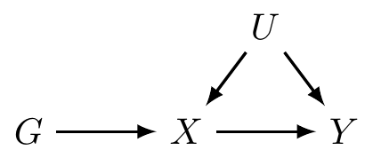

```latex
\begin{tikzpicture}
\node (1) at (0,0) {$G$};
\node (2) at (1.5,0) {$X$};
\node (3) at (3,0) {$Y$};
\node (4) at (2.25,1) {$U$};
\draw[Arrow] (1) -- (2);
\draw[Arrow] (2) -- (3);
\draw[Arrow] (4) -- (2);
\draw[Arrow] (4) -- (3);
\end{tikzpicture}
```

## Multiple genotype DAG using tikz

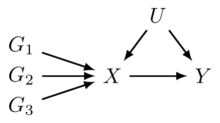

```latex
\begin{tikzpicture}
\node (1) at (0,0) {$G_2$};
\node (2) at (1.5,0) {$X$};
\node (3) at (3,0) {$Y$};
\node (4) at (2.25,1) {$U$};
\node (5) at (0,0.5) {$G_1$};
\node (6) at (0,-0.5) {$G_3$};
\draw[Arrow] (1) -- (2);
\draw[Arrow] (2) -- (3);
\draw[Arrow] (4) -- (2);
\draw[Arrow] (4) -- (3);
\draw[Arrow] (5) -- (2);
\draw[Arrow] (6) -- (2);
\end{tikzpicture}
```

Again this could be extended for more genotypes.

## MVMR DAGs using TikZ

We can plot the DAGs in Figure 4 of Sanderson et al., An examination of multivariable Mendelian randomization in the single-sample and two-sample summary data settings, IJE, 2019, 713-727, [doi:10.1093/ije/dyy262](https://doi.org/10.1093/ije/dyy262) [here](https://academic.oup.com/view-large/figure/162152273/dyy262f4.tif).

- Scenario 1: $X_2$ confounder of $X_1$ and $Y$

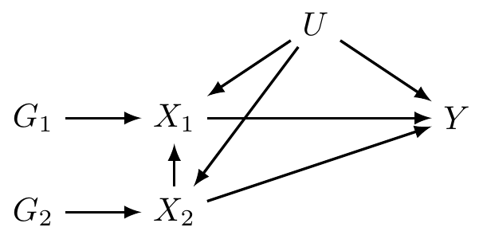

```latex
\begin{tikzpicture}
\node (1) at (0,0) {$G_2$};
\node (2) at (1.5,0) {$X_2$};
\node (3) at (4.5,1) {$Y$};
\node (4) at (3,2) {$U$};
\node (5) at (0,1) {$G_1$};
\node (6) at (1.5,1) {$X_1$};
\draw[Arrow] (1) -- (2);
\draw[Arrow] (2) -- (3);
\draw[Arrow] (4) -- (2);
\draw[Arrow] (4) -- (3);
\draw[Arrow] (5) -- (6);
\draw[Arrow] (6) -- (3);
\draw[Arrow] (4) -- (6);
\draw[Arrow] (2) -- (6);
\end{tikzpicture}
```

- Scenario 2: $X_2$ collider of $X_1$ and $Y$

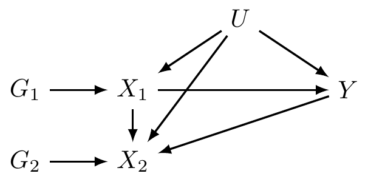

```latex
\begin{tikzpicture}
\node (1) at (0,0) {$G_2$};
\node (2) at (1.5,0) {$X_2$};
\node (3) at (4.5,1) {$Y$};
\node (4) at (3,2) {$U$};
\node (5) at (0,1) {$G_1$};
\node (6) at (1.5,1) {$X_1$};
\draw[Arrow] (1) -- (2);
\draw[Arrow] (3) -- (2);
\draw[Arrow] (4) -- (2);
\draw[Arrow] (4) -- (3);
\draw[Arrow] (5) -- (6);
\draw[Arrow] (6) -- (3);
\draw[Arrow] (4) -- (6);
\draw[Arrow] (6) -- (2);
\end{tikzpicture}
```

- Scenario 3: $X_2$ on a pleiotropic pathway

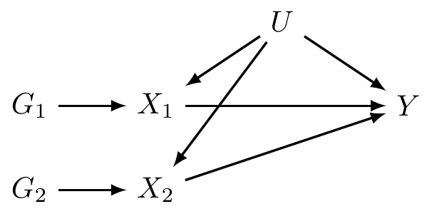

```latex
\begin{tikzpicture}
\node (1) at (0,0) {$G_2$};
\node (2) at (1.5,0) {$X_2$};
\node (3) at (4.5,1) {$Y$};
\node (4) at (3,2) {$U$};
\node (5) at (0,1) {$G_1$};
\node (6) at (1.5,1) {$X_1$};
\draw[Arrow] (1) -- (2);
\draw[Arrow] (2) -- (3);
\draw[Arrow] (4) -- (2);
\draw[Arrow] (4) -- (3);
\draw[Arrow] (5) -- (6);
\draw[Arrow] (6) -- (3);
\draw[Arrow] (4) -- (6);
\end{tikzpicture}
```

- Scenario 4: $X_2$ mediator of the effect of $X_1$ on $Y$

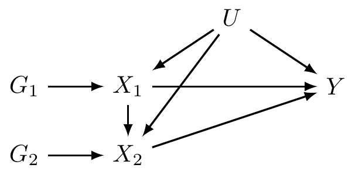

```latex
\begin{tikzpicture}
\node (1) at (0,0) {$G_2$};
\node (2) at (1.5,0) {$X_2$};
\node (3) at (4.5,1) {$Y$};
\node (4) at (3,2) {$U$};
\node (5) at (0,1) {$G_1$};
\node (6) at (1.5,1) {$X_1$};
\draw[Arrow] (1) -- (2);
\draw[Arrow] (2) -- (3);
\draw[Arrow] (4) -- (2);
\draw[Arrow] (4) -- (3);
\draw[Arrow] (5) -- (6);
\draw[Arrow] (6) -- (3);
\draw[Arrow] (4) -- (6);
\draw[Arrow] (6) -- (2);
\end{tikzpicture}
```

# quickdag package

We can produce some nice plots with the quickdag package, which appears to be based on Eleanor Murray’s TikZ code, from [here](https://github.com/jrgant/quickdag)

```r
if (!requireNamespace("quickdag", quietly = TRUE)) remotes::install_github("jrgant/quickdag")

library(quickdag)
edges <- c("G -> X",
           "X -> Y",
           "U -> {X Y}")

# DAG
dag  <- qd_dag(edges)
```

```
##
##
## CHECKED: The diagram is a DAG.
```

```
## Make sure everything is matched up properly!
## To stop printing data to the console, set 'verbose' to FALSE.
```

```
## ........................ NODE DATAFRAME ........................
##
##   id type label alpha.id
## 1  1 <NA>     G        G
## 2  2 <NA>     U        U
## 3  3 <NA>     X        X
## 4  4 <NA>     Y        Y
##
## ........................ EDGE DATAFRAME ........................
##
##   id from to  rel
## 1  1    1  3 <NA>
## 2  2    3  4 <NA>
## 3  3    2  3 <NA>
## 4  4    2  4 <NA>
```

```r
dag %>% render_graph()
```

[interactive chart not shown]

We can also draw the single world intervention graph (SWIG) for the IV model as follow.

```r
# SWIG
swig <- dag %>%
  qd_swig(fixed.nodes = c("G","X"),
          custom.labels = c("G" = "g",
                            "X" = "x"))
swig %>% render_graph()
```

[interactive chart not shown]

# Thomas Richardson’s TikZ code for SWIGs

Thomas Richardson provides a TikZ/PGF shape library for SWIGs called tikz-swigs, which is available on CTAN [here](https://ctan.org/pkg/tikz-swigs).

- Install the package into your TinyTeX installation with

  ```r
  tinytex::install_tlmgr("tikz-swigs")
  ```

- Its user manual is available [here](http://mirrors.ctan.org/graphics/pgf/contrib/tikz-swigs/tikz-swigs.pdf)

To use the tikz chunk engine we again write a LaTeX template based on the preamble in the article by Richardson. The LaTeX template is as follows.

```latex
\documentclass{article}
\usepackage[active,tightpage]{preview}
\usepackage{amsmath}
\usepackage{pgf,tikz}
\usetikzlibrary{arrows,shapes.arrows,shapes.geometric,shapes.multipart,
decorations.pathmorphing,positioning,swigs}

\begin{document}
\begin{preview}
%% TIKZ_CODE %%
\end{preview}
\end{document}
```

## SWIGs for single exposure models

We will recreate the SWIG template in Figure 2 (b) of Swanson et al. [here](https://doi.org/10.1080/01621459.2018.1434530).

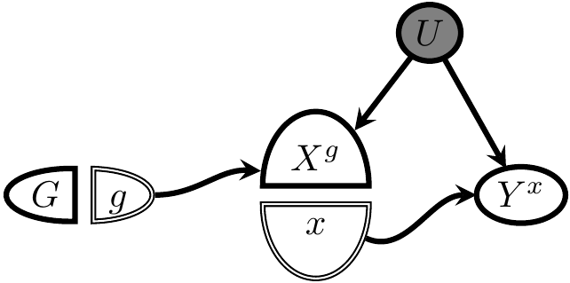

```latex
\begin{tikzpicture}
\tikzset{line width=1.5pt, outer sep=0pt,
  ell/.style={draw, fill=white, inner sep=2pt,
  line width=1.5pt},
  swig vsplit={gap=5pt, inner line width right=0.5pt},
  swig hsplit={gap=5pt, inner line width lower=0.5pt}};

\node[name=G, shape=swig vsplit]{
\nodepart{left}{$G$}
\nodepart{right}{$g$}};

\node[name=X, right=10mm of G,
  shape=swig hsplit]{
\nodepart{upper}{$X^g$}
\nodepart{lower}{$x$}};

\node[name=U, ell, shape=ellipse, above right=7.5mm and 5mm of X, fill=gray]{$U$};

\node[name=Y, ell, shape=ellipse, right=10mm of X]{$Y^x$};

\draw[->, line width=1.5pt,>=stealth]
  (G) edge[out=360, in=170] (X)
  (U) edge (X)
  (U) edge (Y)
  (X) to[out=330, in=180] (Y);
\end{tikzpicture}
```

Let’s add colour in the same way as in the original figure.

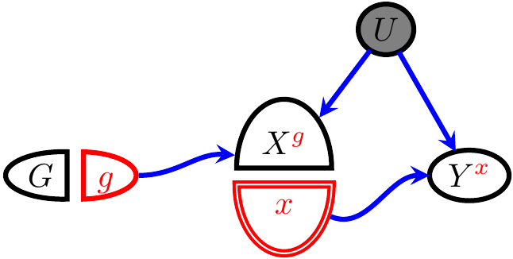

```latex
\begin{tikzpicture}
\tikzset{line width=1.5pt, outer sep=0pt,
  ell/.style={draw, fill=white, inner sep=2pt,
  line width=1.5pt},
  swig vsplit={gap=5pt},
  swig hsplit={gap=5pt, inner line width lower=0.5pt}};

\node[name=G, shape=swig vsplit,
  swig vsplit={line color right=red}]{
\nodepart{left}{$G$}
\nodepart{right}{\textcolor{red}{$g$}}};

\node[name=X, right=10mm of G,
  shape=swig hsplit,
  swig hsplit = {line color lower=red,
                 line width lower=2.5pt}]{
\nodepart{upper}{$X^{\textcolor{red}{g}}$}
\nodepart{lower}{\textcolor{red}{$x$}}};

\node[name=U, ell, shape=ellipse, above right=7.5mm and 5mm of X, fill=gray]{$U$};

\node[name=Y, ell, shape=ellipse, right=10mm of X]{$Y^{\textcolor{red}{x}}$};

\draw[->, line width=1.5pt,>=stealth, color=blue]
  (G) edge[out=360, in=170] (X)
  (U) edge (X)
  (U) edge (Y)
  (X) to[out=330, in=180] (Y);
\end{tikzpicture}
```

## SWIGs for MVMR models

Let’s attempt the SWIG for the multivariable Mendelian randomization (MVMR) model.

### SWIG for MVMR model with 2 independent exposures

Since $G_1$ an instrument for both $X_1$ and $X_2$, $X_2$ represents a pleiotropic effect in this case.

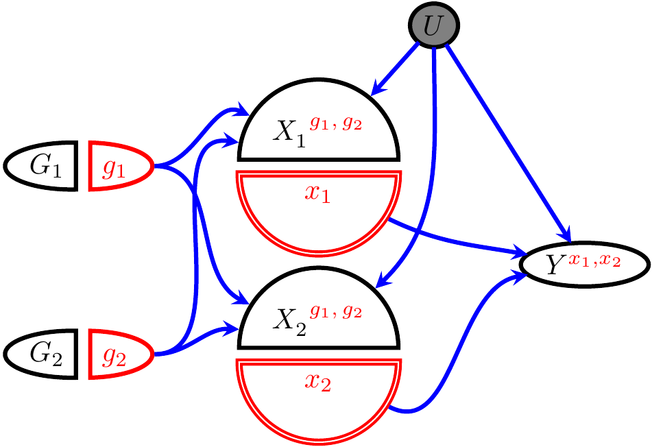

```latex
\begin{tikzpicture}
\tikzset{line width=1.5pt, outer sep=0pt,
  ell/.style={draw, fill=white, inner sep=2pt,
  line width=1.5pt},
  swig vsplit={gap=5pt},
  swig hsplit={gap=5pt, inner line width lower=0.5pt}};

\node[name=G1,
  shape=swig vsplit,
  swig vsplit={line color right=red}]{
\nodepart{left}{$G_1$}
\nodepart{right}{\textcolor{red}{$g_1$}}};

\node[name=X1,
  right=10mm of G1,
  shape=swig hsplit,
  swig hsplit = {line color lower=red,
                 line width lower=2.5pt}]{
\nodepart{upper}{$X_1^{\phantom{1}\textcolor{red}{g_1,\,g_2}}$}
\nodepart{lower}{\textcolor{red}{$x_1$}}};

\node[name=X2,
  below = 1mm of X1,
  shape=swig hsplit,
  swig hsplit = {line color lower=red,
                 line width lower=2.5pt}]{
\nodepart{upper}{$X_2^{\phantom{2}\textcolor{red}{g_1,\,g_2}}$}
\nodepart{lower}{\textcolor{red}{$x_2$}}};

\node[name=G2,
  left = 10mm of X2,
  shape=swig vsplit,
  swig vsplit={line color right=red}]{
\nodepart{left}{$G_2$}
\nodepart{right}{\textcolor{red}{$g_2$}}};

\node[name=U,
  ell,
  shape=ellipse,
  above right=7.5mm and 5mm of X1,
  fill=gray]{$U$};

\node[name=Y,
  ell,
  shape=ellipse,
  below right=2mm and 20mm of X1]{$Y^{\textcolor{red}{x_1, x_2}}$};

\draw[->, line width=1.5pt,>=stealth, color=blue]
  (G1) edge[out=360, in=150] (X1)
  (G1) edge[out=360, in=150] (X2)
  (G2) edge[out=360, in=170] (X2)
  (G2) edge[out=360, in=170] (X1)
  (U) edge (X1)
  (U) edge[out=270, in=45] (X2)
  (U) edge (Y)
  (X1) edge[out=330, in=170] (Y)
  (X2) to[out=330, in=190] (Y);
\end{tikzpicture}
```

### SWIG for MVMR model with $X_2$ confounder of $X_1$–$Y$

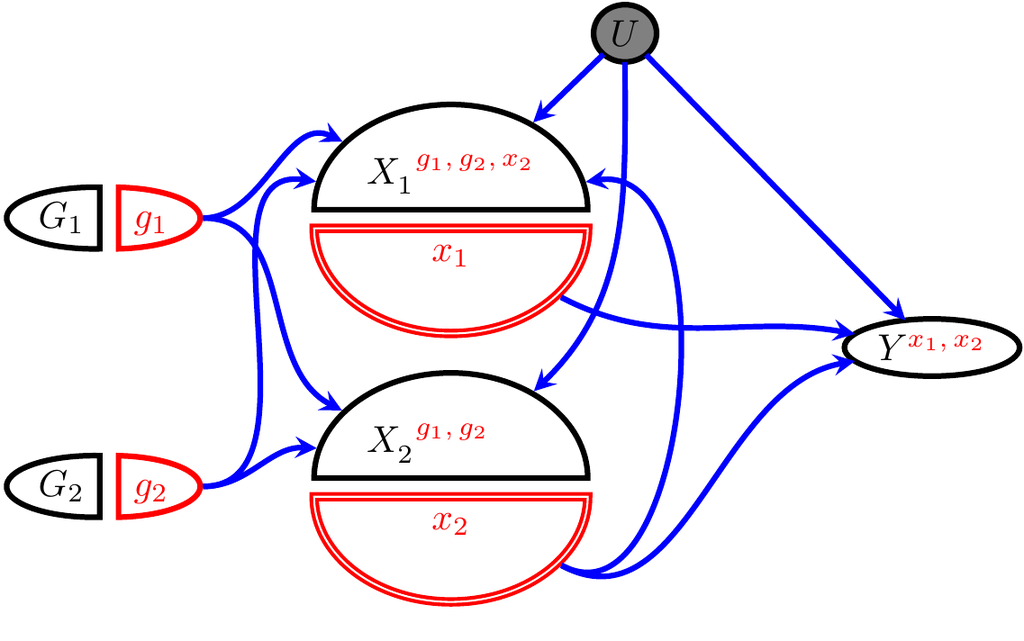

```latex
\begin{tikzpicture}
\tikzset{line width=1.5pt, outer sep=0pt,
  ell/.style={draw, fill=white, inner sep=2pt,
  line width=1.5pt},
  swig vsplit={gap=5pt},
  swig hsplit={gap=5pt, inner line width lower=0.5pt}};

\node[name=G1,
  shape=swig vsplit,
  swig vsplit={line color right=red}]{
\nodepart{left}{$G_1$}
\nodepart{right}{\textcolor{red}{$g_1$}}};

\node[name=X1,
  right=10mm of G1,
  shape=swig hsplit,
  swig hsplit = {line color lower=red,
                 line width lower=2.5pt}]{
\nodepart{upper}{$X_1^{\phantom{1}\textcolor{red}{g_1,\,g_2,\,x_2}}$}
\nodepart{lower}{\textcolor{red}{$x_1$}}};

\node[name=X2,
  below = 3mm of X1,
  shape=swig hsplit,
  swig hsplit = {line color lower=red,
                 line width lower=2.5pt}]{
\nodepart{upper}{$X_2^{\phantom{2}\textcolor{red}{g_1,\,g_2}\phantom{,\,x_2}}$}
\nodepart{lower}{\textcolor{red}{$x_2$}}};

\node[name=G2,
  left = 10mm of X2,
  shape=swig vsplit,
  swig vsplit={line color right=red}]{
\nodepart{left}{$G_2$}
\nodepart{right}{\textcolor{red}{$g_2$}}};

\node[name=U,
  ell,
  shape=ellipse,
  above right=7.5mm and 5mm of X1,
  fill=gray]{$U$};

\node[name=Y,
  ell,
  shape=ellipse,
  below right=2mm and 30mm of X1]{$Y^{\textcolor{red}{x_1,\,x_2}}$};

\draw[->, line width=1.5pt,>=stealth, color=blue]
  (G1) edge[out=360, in=150] (X1)
  (G1) edge[out=360, in=150] (X2)
  (G2) edge[out=360, in=170] (X2)
  (G2) edge[out=360, in=170] (X1)
  (U) edge (X1)
  (U) edge[out=270, in=45] (X2)
  (U) edge (Y)
  (X2) edge[out=330, in=10] (X1)
  (X1) edge[out=330, in=170] (Y)
  (X2) to[out=330, in=190] (Y);
\end{tikzpicture}
```

### SWIG for MVMR model with $X_2$ collider of $X_1$–$Y$

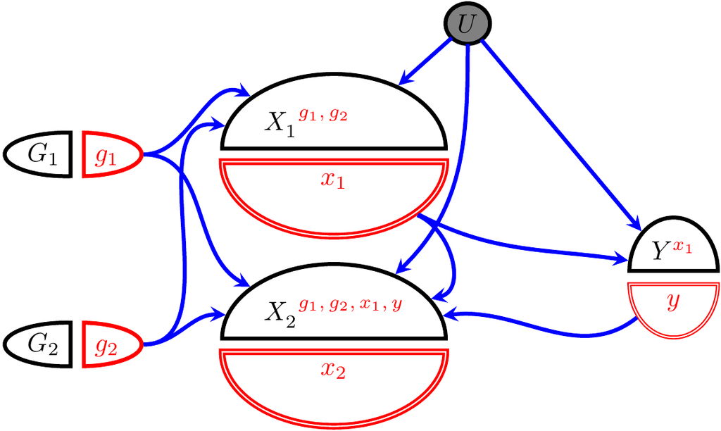

```latex
\begin{tikzpicture}
\tikzset{line width=1.5pt, outer sep=0pt,
  ell/.style={draw, fill=white, inner sep=2pt,
  line width=1.5pt},
  swig vsplit={gap=5pt},
  swig hsplit={gap=5pt, inner line width lower=0.5pt}};

\node[name=G1,
  shape=swig vsplit,
  swig vsplit={line color right=red}]{
\nodepart{left}{$G_1$}
\nodepart{right}{\textcolor{red}{$g_1$}}};

\node[name=X1,
  right=10mm of G1,
  shape=swig hsplit,
  swig hsplit = {line color lower=red,
                 line width lower=2.5pt}]{
\nodepart{upper}{$X_1^{\phantom{1}\textcolor{red}{g_1,\,g_2\phantom{,\,x_1,\,y}}}$}
\nodepart{lower}{\textcolor{red}{$x_1$}}};

\node[name=X2,
  below = 3mm of X1,
  shape=swig hsplit,
  swig hsplit = {line color lower=red,
                 line width lower=2.5pt}]{
\nodepart{upper}{$X_2^{\phantom{2}\textcolor{red}{g_1,\,g_2,\,x_1,\,y}}$}
\nodepart{lower}{\textcolor{red}{$x_2$}}};

\node[name=G2,
  left = 10mm of X2,
  shape=swig vsplit,
  swig vsplit={line color right=red}]{
\nodepart{left}{$G_2$}
\nodepart{right}{\textcolor{red}{$g_2$}}};

\node[name=U,
  ell,
  shape=ellipse,
  above right=7.5mm and 5mm of X1,
  fill=gray]{$U$};

\node[name=Y,
  shape=swig hsplit,
  swig hsplit={line color lower=red},
  below right=2mm and 30mm of X1]{
  \nodepart{upper}{$Y^{\textcolor{red}{x_1}}$}
  \nodepart{lower}{$\textcolor{red}{y}$}};

\draw[->, line width=1.5pt,>=stealth, color=blue]
  (G1) edge[out=360, in=150] (X1)
  (G1) edge[out=360, in=150] (X2)
  (G2) edge[out=360, in=170] (X2)
  (G2) edge[out=360, in=170] (X1)
  (U) edge (X1)
  (U) edge[out=270, in=45] (X2)
  (U) edge (Y)
  (X1) edge[out=330, in=20] (X2)
  (X1) edge[out=330, in=170] (Y)
  (Y) to[out=220, in=10] (X2);
\end{tikzpicture}
```

### SWIG for MVMR model with $X_2$ mediator of $X_1$–$Y$

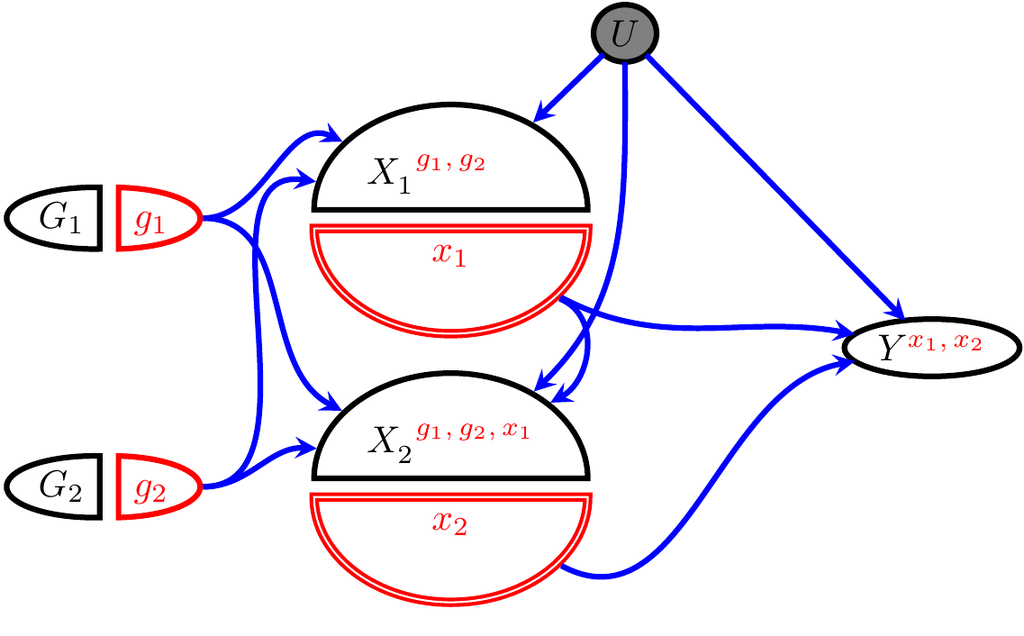

```latex
\begin{tikzpicture}
\tikzset{line width=1.5pt, outer sep=0pt,
  ell/.style={draw, fill=white, inner sep=2pt,
  line width=1.5pt},
  swig vsplit={gap=5pt},
  swig hsplit={gap=5pt, inner line width lower=0.5pt}};

\node[name=G1,
  shape=swig vsplit,
  swig vsplit={line color right=red}]{
\nodepart{left}{$G_1$}
\nodepart{right}{\textcolor{red}{$g_1$}}};

\node[name=X1,
  right=10mm of G1,
  shape=swig hsplit,
  swig hsplit = {line color lower=red,
                 line width lower=2.5pt}]{
\nodepart{upper}{$X_1^{\phantom{1}\textcolor{red}{g_1,\,g_2\phantom{,\,x_2}}}$}
\nodepart{lower}{\textcolor{red}{$x_1$}}};

\node[name=X2,
  below = 3mm of X1,
  shape=swig hsplit,
  swig hsplit = {line color lower=red,
                 line width lower=2.5pt}]{
\nodepart{upper}{$X_2^{\phantom{2}\textcolor{red}{g_1,\,g_2,\,x_1}}$}
\nodepart{lower}{\textcolor{red}{$x_2$}}};

\node[name=G2,
  left = 10mm of X2,
  shape=swig vsplit,
  swig vsplit={line color right=red}]{
\nodepart{left}{$G_2$}
\nodepart{right}{\textcolor{red}{$g_2$}}};

\node[name=U,
  ell,
  shape=ellipse,
  above right=7.5mm and 5mm of X1,
  fill=gray]{$U$};

\node[name=Y,
  ell,
  shape=ellipse,
  below right=2mm and 30mm of X1]{$Y^{\textcolor{red}{x_1,\,x_2}}$};

\draw[->, line width=1.5pt,>=stealth, color=blue]
  (G1) edge[out=360, in=150] (X1)
  (G1) edge[out=360, in=150] (X2)
  (G2) edge[out=360, in=170] (X2)
  (G2) edge[out=360, in=170] (X1)
  (U) edge (X1)
  (U) edge[out=270, in=45] (X2)
  (U) edge (Y)
  (X1) edge[out=330, in=35] (X2)
  (X1) edge[out=330, in=170] (Y)
  (X2) to[out=330, in=190] (Y);
\end{tikzpicture}
```